# Formatted and Flexible Correlation Tables

Dominique Makowski

2018-05-11

# Another *correlation* function?!

Yes, the `correlation` function from the [`psycho`](https://github.com/neuropsychology/psycho.R) package.

```r
library(psycho)
library(tidyverse)

cor <- psycho::affective %>%
  correlation()
```

This function automatically select numeric variables and run a correlation analysis. It returns a `psychobject`.

# A table

We can then extract a **formatted table** that can be saved and pasted into reports and manuscripts.

```r
summary(cor)
# write.csv(summary(cor), "myformattedcortable.csv")
```

|  | Age | Life_Satisfaction | Concealing | Adjusting |
| --- | --- | --- | --- | --- |
| Age |  |  |  |  |
| Life_Satisfaction | 0.03 |  |  |  |
| Concealing | -0.05 | -0.06 |  |  |
| Adjusting | 0.03 | 0.36*** | 0.22*** |  |
| Tolerating | 0.03 | 0.15*** | 0.07 | 0.29*** |

# A Plot

It integrates a **plot** done with [`ggcorplot`](https://github.com/kassambara/ggcorrplot).

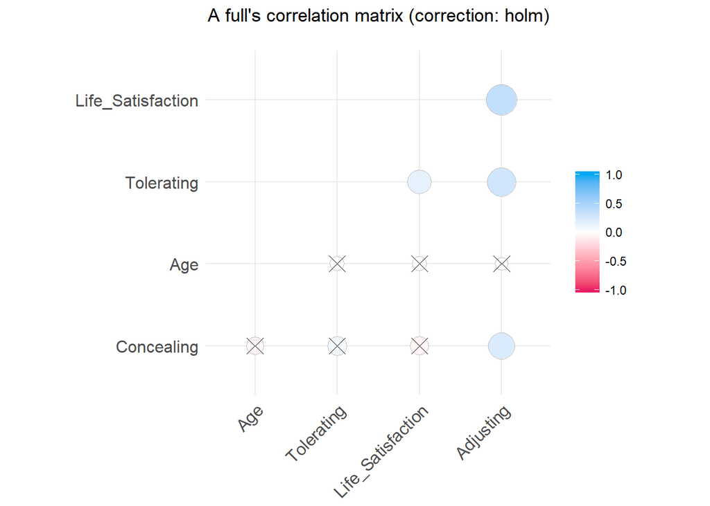

```r
plot(cor)
```

# A print

It also includes a **pairwise correlation printing** method.

```r
print(cor)
```

```
Pearson Full Correlation (p value correction: holm):
   - Age - Life_Satisfaction:   Results of the Pearson correlation showed a non significant and weak negative association between Age and Life_Satisfaction (r(1249) = 0.030, p > .1).
   - Age - Concealing:   Results of the Pearson correlation showed a non significant and weak positive association between Age and Concealing (r(1249) = -0.050, p > .1).
   - Life_Satisfaction - Concealing:   Results of the Pearson correlation showed a non significant and weak positive association between Life_Satisfaction and Concealing (r(1249) = -0.063, p > .1).
   - Age - Adjusting:   Results of the Pearson correlation showed a non significant and weak negative association between Age and Adjusting (r(1249) = 0.027, p > .1).
   - Life_Satisfaction - Adjusting:   Results of the Pearson correlation showed a significant and moderate negative association between Life_Satisfaction and Adjusting (r(1249) = 0.36, p < .001***).
   - Concealing - Adjusting:   Results of the Pearson correlation showed a significant and weak negative association between Concealing and Adjusting (r(1249) = 0.22, p < .001***).
   - Age - Tolerating:   Results of the Pearson correlation showed a non significant and weak negative association between Age and Tolerating (r(1249) = 0.031, p > .1).
   - Life_Satisfaction - Tolerating:   Results of the Pearson correlation showed a significant and weak negative association between Life_Satisfaction and Tolerating (r(1249) = 0.15, p < .001***).
   - Concealing - Tolerating:   Results of the Pearson correlation showed a non significant and weak negative association between Concealing and Tolerating (r(1249) = 0.074, p = 0.05°).
   - Adjusting - Tolerating:   Results of the Pearson correlation showed a significant and weak negative association between Adjusting and Tolerating (r(1249) = 0.29, p < .001***).
```

# Options

You can also cutomize the **type** (pearson, spearman or kendall), the **p value correction method** (holm (default), bonferroni, fdr, none…) and run **partial, semi-partial or glasso** correlations.

```r
psycho::affective %>%
  correlation(method = "pearson", adjust="bonferroni", type="partial") %>%
  summary()
```

|  | Age | Life_Satisfaction | Concealing | Adjusting |
| --- | --- | --- | --- | --- |
| Age |  |  |  |  |
| Life_Satisfaction | 0.01 |  |  |  |
| Concealing | -0.06 | -0.16*** |  |  |
| Adjusting | 0.02 | 0.36*** | 0.25*** |  |
| Tolerating | 0.02 | 0.06 | 0.02 | 0.24*** |

# Fun with *p*-hacking

In order to **prevent people for running many uncorrected correlation tests** (promoting *p*-hacking and result-fishing), we included the `i_am_cheating` parameter. If FALSE (default), the function will help you finding interesting results!

```r
df_with_11_vars <- data.frame(replicate(11, rnorm(1000)))
cor <- correlation(df_with_11_vars, adjust="none")
summary(cor)
```

|  | X1 | X2 | X3 | X4 | X5 | X6 | X7 | X8 | X9 | X10 | X11 |
| --- | --- | --- | --- | --- | --- | --- | --- | --- | --- | --- | --- |
| X1 |  |  |  |  |  |  |  |  |  |  |  |
| X2 | -0.01 |  |  |  |  |  |  |  |  |  |  |
| X3 | -0.04 | -0.06 |  |  |  |  |  |  |  |  |  |
| X4 | 0.00 | -0.02 | 0.01 |  |  |  |  |  |  |  |  |
| X5 | 0.01 | -0.06 | -0.04 | -0.01 |  |  |  |  |  |  |  |
| X6 | 0.00 | 0.02 | -0.01 | -0.02 | 0.00 |  |  |  |  |  |  |
| X7 | 0.02 | 0.01 | -0.04 | -0.03 | 0.01 | 0.02 |  |  |  |  |  |
| X8 | 0.01 | 0.00 | 0.01 | 0.07* | 0.08* | 0.00 | -0.03 |  |  |  |  |
| X9 | -0.03 | 0.02 | 0.00 | 0.00 | 0.03 | -0.01 | -0.01 | 0.08* |  |  |  |
| X10 | -0.07* | 0.10** | 0.03 | 0.04 | 0.00 | -0.03 | -0.02 | 0.01 | -0.02 |  |  |
| X11 | -0.02 | -0.03 | 0.03 | -0.04 | 0.04 | -0.02 | -0.01 | 0.01 | -0.03 | 0.00 |  |
| Local_Air_Density | 0.24*** | -0.66*** | 0.02 | -0.12*** | 0.38*** | -0.03 | 0.04 | 0.08** | -0.03 | -0.60*** | 0.35*** |
| Reincarnation_Cycle | -0.02 | -0.08* | -0.01 | -0.08** | 0.00 | 0.02 | 0.06 | -0.04 | 0.04 | -0.02 | -0.04 |
| Communism_Level | 0.20*** | 0.07* | -0.17*** | -0.33*** | -0.34*** | 0.32*** | 0.26*** | -0.53*** | -0.58*** | -0.23*** | -0.08* |
| Alien_Mothership_Distance | -0.01 | 0.00 | 0.01 | -0.03 | 0.01 | 0.05 | -0.02 | -0.05 | 0.03 | -0.02 | 0.04 |
| Schopenhauers_Optimism | 0.22*** | 0.14*** | -0.33*** | -0.03 | 0.16*** | 0.46*** | 0.17*** | 0.19*** | 0.47*** | -0.31*** | -0.54*** |
| Hulks_Power | 0.00 | -0.01 | 0.01 | 0.00 | -0.02 | -0.01 | 0.00 | -0.03 | 0.03 | -0.03 | -0.04 |

**As we can see, Schopenhauer’s Optimism is strongly related to many variables!!!**

# Credits

This package was useful? You can cite [`psycho`](https://github.com/neuropsychology/psycho.R) as follows:

- Makowski, (2018). *The psycho Package: an Efficient and Publishing-Oriented Workflow for Psychological Science*. Journal of Open Source Software, 3(22), 470. https://doi.org/10.21105/joss.00470